# BIO300A_data

Author

Hanif Kawousi

Published

October 13, 2023

For the BIO300A-assignment, we are looking to answer the following question:

how does the types of linear infrastructure (roads, highways, powerlines, etc.) affects the local wildlife.

this is a broad question, but it allows for multiple hypothesis.

Our data is from dejounge et al 2022: https://onlinelibrary.wiley.com/doi/10.1111/gcb.16450. They provided a metaanalysis spanning from 1973 - 2018, where as we are looking at data from 2010 until 2018. In doing so, we hope to see data more aligned with modern day sightings.

our null-Hypothesis is as follows: There are no significant differences in how the different types of roads affects the presence of surrounding wildlife.

The background for our hypothesis is the ongoing debate in Norway regarding the building of landbased windmills, powerlines, roads, etc., and in the cost this will have on nature. Many argue that pristine landscapes will be permanently damaged and that it is the wildlife that will pay the dire price, and in extent the stakeholders. Although, there is a long tradition for cabins amongst scandinavians. Small villages of cabins are often built where there previously were none, and the building of roads where cars can travel have therefore also been built for cabin access. This presents us with an issue: How does these roads differ in the impact on the surrounding mobile wildlife (non-vegetation)?

Therefore, we want to know based on the metastudy of Dejonge et als data, in what sense does infrastructures affect wildlife presence? Is this more or less than average unpaved roads made for recreational trekking and the like?

Both T-test and p-value are good tests. We can also make graphs showing this: Box-plot. ANOVA-model!

importing libraries

```r
library(tidyverse)
library(readr)
library(tidyr)
library(dplyr)
library(patchwork)
library(stats)
```

importing data

```r
dejonge_dataset <- read_csv("data/dejonge_data/2022_deJonge_Dataset_092022.csv")|>
                                select(StudyYear, Country, Longitude, Latitude,
                                       Group, SpeciesName, AbundanceUnit,
                                       InfraAbundance_original,
                                       ControlAbundance_original, InfraA,
                                       ControlA, InfraN, ControlN,
                                       InfraType, Dist, CDist, MinDist,
                                       MaxDist, MinCDist, MaxCDist) |>
  na.omit(dejonge_dataset)
#abundance. We use this function in the anova-model below, as well as the boxplot.
dejonge_dataset_abundance <- dejonge_dataset |>
  filter(StudyYear >= 2010) |>
  select( Group, InfraA, ControlA, InfraType)


#distribution of means Linear Infrastructure

dejonge_dataset_mean <- dejonge_dataset_abundance |>
  group_by(InfraType) |>
  summarise(mean_abundance = mean(InfraA)) |>
  arrange(mean_abundance)

#distribution of means Linear Infrastructure control

dejonge_dataset_mean_control <- dejonge_dataset_abundance |>
  group_by(InfraType) |>
  summarise(mean_abundance_C = mean(ControlA)) |>
  arrange(mean_abundance_C)
```

```r
#anova-model
aov_model <- aov(InfraA ~ InfraType, data = dejonge_dataset_abundance)

summary(aov_model)
```

```
             Df Sum Sq Mean Sq F value  Pr(>F)
InfraType     3    269   89.83   4.093 0.00681 **
Residuals   655  14376   21.95
---
Signif. codes:  0 '***' 0.001 '**' 0.01 '*' 0.05 '.' 0.1 ' ' 1
```

**P-value is less than 0.05 or 5%**, meaning that our null-hypothesis: *“There are no significant differences in how the different types of roads affects the presence of surrounding wildlife.”* is **false**!

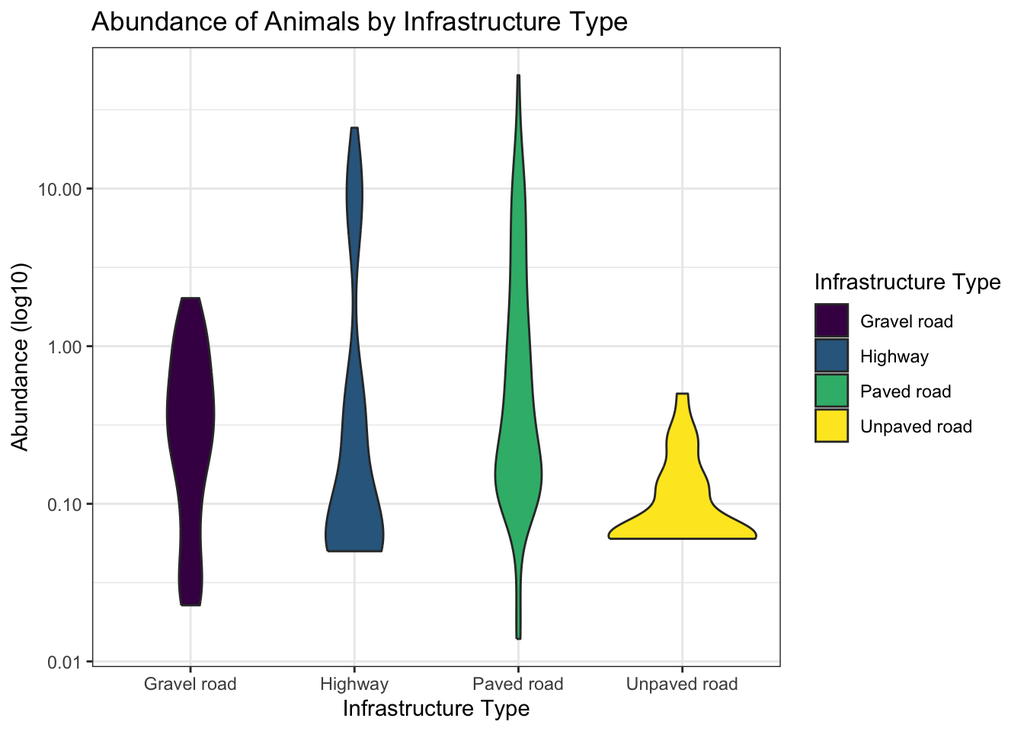

```r
#graphic display of anova-model:
abundance_infratype_boxplot <- ggplot(dejonge_dataset_abundance,
                            aes(x = InfraType,
                                y =  InfraA, fill = InfraType)) +
  geom_violin() +
  labs(x = "Infrastructure Type", y = "Abundance (log10)", fill = "Infrastructure Type") +
  ggtitle("Abundance of Animals by Infrastructure Type") +
  theme_bw()

abundance_infratype_boxplot + scale_y_log10() + scale_fill_viridis_d()
```

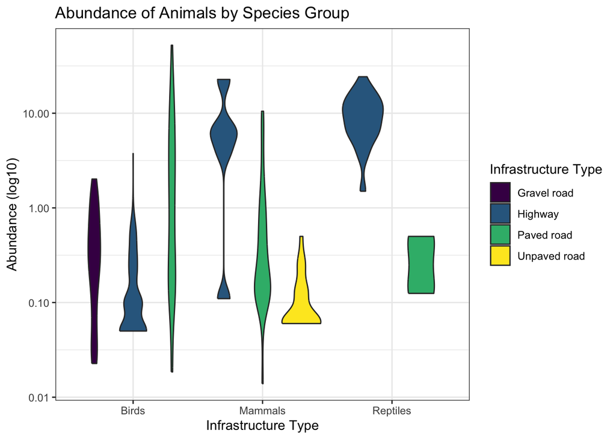

```r
abundance_animalgroup_boxplot <- ggplot(dejonge_dataset_abundance,
                            aes(x = Group,
                                y =  InfraA, fill = InfraType)) +
  geom_violin() +
  labs(x = "Infrastructure Type", y = "Abundance (log10)", fill = "Infrastructure Type") +
  ggtitle("Abundance of Animals by Species Group") +
  theme_bw()

abundance_animalgroup_boxplot + scale_y_log10() + scale_fill_viridis_d()
```